# QA/QC Report

##QA/QC of position & depth

### Look for major positional errors

**Latitude**  
Mean: 31.6071085  
Maximum: 36.23126  
Minimum: 29.36672  
*No glaring latitude errors according to max and min*

**Longitude**  
Mean: -77.6260489  
Maximum: -74.46281  
Minimum: -79.72947  
*No glaring longitude errors according to max and min*

Static map to visualize dive locations and highlight any glaring positional issues.

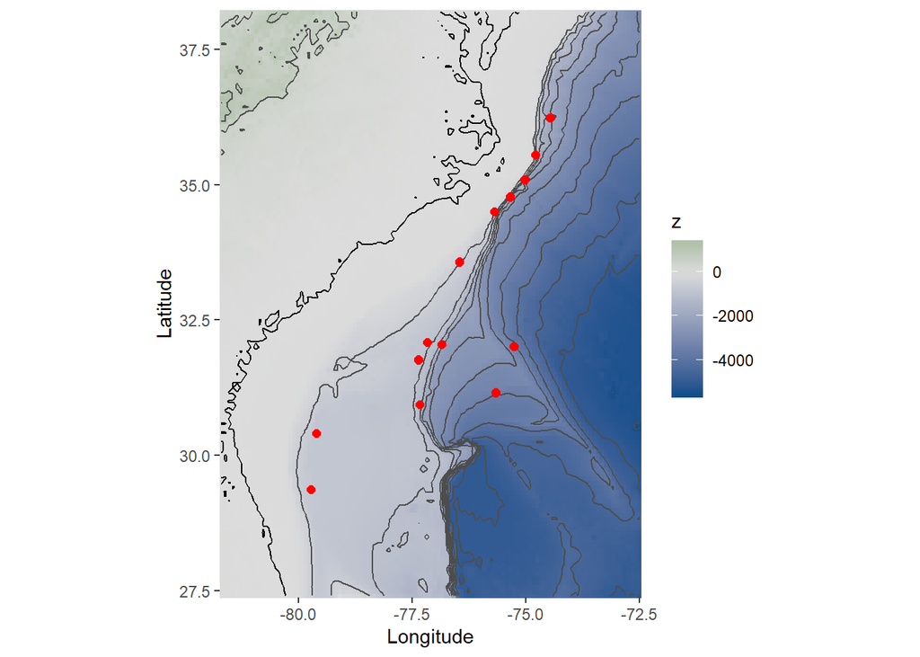

### Interactive Map of Dive Lines & Occurrences (to check for finer scale positional errors)

The dive tracks are pulled directly from NCEI online (no csv was downloaded to plot the dive tracks). Your observation points are overlaid on those divelines

**Instructions**

Zoom in to points to see if they fall on the diveline. If they don’t, you can click on the point and a pop-up will appear that shows you the Dive, ScientificName, SampleID, Latitude, and Longitude so that you can go to the observation in your excel sheet and then see if there are changes that need to be made.

You will have to go on SeaTube to get correct positional data for your observations. The positional data very well could be correct yet might look off on the map because of differences in the navigation data or numerous other issues that aren’t on us. Many depth errors stem from small latitude/longitude errors so making sure that these correct will be important downstream in this document when the depths are checked.

[interactive chart not shown]

### Interactive Map Showing Annotations > 20 m Off The Dive Track

A 20 m buffer was created around each dive track and then a test was run to determine if any points from your data fall outside of this buffer. Only points that fall outside of this buffer are shown on the map in red.

**Instructions**

Zoom in to each of those points and click on them to see the information for that point so that you can go into your spreadsheet and find the annotation. You will likely have to go on seatube to double check that the positional data is correct.

```
## [1] "Feature Layer"
## [1] "esriGeometryPolyline"
```

[interactive chart not shown]

### Depth check

#### Test OBIS vs. GEBCO 2019

These are linear regression plots showing the depths from OBIS or from the GEBCO 2019 raster compared to the depths for each of the annotations. The t-value (how well your annotation depths fit the depths available from OBIS or GEBCO 2019, larger t-value = better fit) is displayed along with the number of annotations that have a depth difference > 15%.

**This shows you that GEBCO 2019 is the best bathymetry raster we have to compare our annotation depths too**

*ETOPO1 is even worse than OBIS*

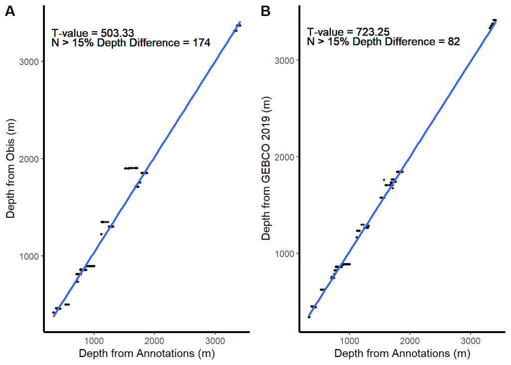

#### Leaflet Map using GEBCO 2019

*Only displays those that have a depth difference error of $\ge$ 15% (could be depth or could be lat/long errors)*

**Instructions** As with the map before, you may zoom in and click on circle markers to view a popup of the data properties that will allow you to find the annotation based on the SampleID. The popup also has the depth recorded for the annotation and the depth according the GEBCO 2019 raster.

Number of Annotations with > 15% depth difference with GEBCO 2019: 82

[interactive chart not shown]

## Smithsonian USNM Number & Species Name Check

This pulls records from Smithsonian using the `rgbif` package.

**Instructions**

The first table contains the coral and sponge records from the Smithsonian so that you can check your records in the second table with theirs. This will allow you to see the OER ID/SampleID , and the USNM number. You will also be able to see if the specimen has been given a better ID by the Smithsonian since it was collected. If there have been updates to the identification of the specimen, you will need to make these changes in your data sheet.

This is a table that shows where your annotations SampleID **matches** the Smithsonian SampleID, the USNM Number, and the taxonomy that the Smithsonian has for it.  
**Make sure that your ScientificName and any other taxonomic information is updated to what the Smithsonian has**  
**Also make sure that you replace the SampleID with the USNM number and put the OER Sample string in the column that Tom wants**

#### Records with matches

| SampleID | USNMNumber | YourScientificName | USNMScientificName | acceptedScientificName | phylum | order | family | genus | species | Latitude | Longitude | DepthInMeters | Locality | ObservationDate | ObservationTime |
| --- | --- | --- | --- | --- | --- | --- | --- | --- | --- | --- | --- | --- | --- | --- | --- |
| D2_DIVE08_SPEC05BIO | 1490609 | Scleractinia | Bathypsammia tintinnabulum (Pourtalès, 1868) | Bathypsammia tintinnabulum (Pourtalès, 1868) | Cnidaria | Scleractinia | Dendrophylliidae | Bathypsammia | Bathypsammia tintinnabulum | 32.09338 | -77.16325 | 888.2 | Blake Plateau | 6/22/2018 | 18:32:39 |
| D2_DIVE06_SPEC01BIO | 1490568 | Hexactinellida | Hexactinellida | Hexactinellida | Porifera | NA | NA | NA | NA | 30.40376 | -79.59853 | 778.0 | Blake Plateau | 6/20/2018 | 15:34:36 |
| D2_DIVE08_SPEC06BIO | 1490612 | Cladorhizidae | Chondrocladia Thomson, 1873 | Chondrocladia Thomson, 1873 | Porifera | Poecilosclerida | Cladorhizidae | Chondrocladia | NA | 32.09334 | -77.16375 | 881.0 | Blake Plateau | 6/22/2018 | 18:56:05 |
| D2_DIVE02_SPEC03BIO | 1490539 | Geodia sp. | Geodia pachydermata (Sollas, 1886) | Geodia pachydermata (Sollas, 1886) | Porifera | Tetractinellida | Geodiidae | Geodia | Geodia pachydermata | 32.01244 | -75.26090 | 3378.0 | Blake Ridge | 6/15/2018 | 17:15:46 |
| D2_DIVE06_SPEC04BIO | 1490573 | Porifera | Dercitus Gray, 1867 | Dercitus Gray, 1867 | Porifera | Tetractinellida | Ancorinidae | Dercitus | NA | 30.40539 | -79.60171 | 720.0 | Blake Plateau | 6/20/2018 | 19:42:18 |
| D2_DIVE06_SPEC04BIO_A02 | 1490575 | Nephtheidae | Duva florida (Rathke, 1806) | Duva florida (Rathke, 1806) | Cnidaria | Alcyonacea | Nephtheidae | Duva | Duva florida | 30.40539 | -79.60171 | 720.0 | Blake Plateau | 6/20/2018 | 19:42:18 |
| D2_DIVE04_SPEC09BIO | 1490549 | Leiopathes sp. | Leiopathes glaberrima (Esper, 1788) | Leiopathes glaberrima (Esper, 1788) | Cnidaria | Antipatharia | Leiopathidae | Leiopathes | Leiopathes glaberrima | 30.94142 | -77.33009 | 1248.0 | Blake Plateau | 6/17/2018 | 18:55:44 |
| D2_DIVE04_SPEC01BIO | 1490546 | Stauropathes sp. | Stauropathes punctata (Roule, 1905) | Stauropathes punctata (Roule, 1905) | Cnidaria | Antipatharia | Schizopathidae | Stauropathes | Stauropathes punctata | 30.94017 | -77.32859 | 1321.1 | Blake Plateau | 6/17/2018 | 13:47:23 |
| D2_DIVE01_SPEC01BIO | 1490531 | Porifera | Demospongiae | Demospongiae | Porifera | NA | NA | NA | NA | 32.05389 | -76.84633 | 1684.0 | Blake Escarpment | 6/14/2018 | 17:12:33 |
| D2_DIVE04_SPEC02BIO | 1490547 | Bathypathes sp. | Bathypathes Brook, 1889 | Bathypathes Brook, 1889 | Cnidaria | Antipatharia | Schizopathidae | Bathypathes | NA | 30.94012 | -77.32856 | 1321.0 | Blake Plateau | 6/17/2018 | 13:50:23 |
| D2_DIVE05_SPEC03BIO | 1490556 | Duva florida | Duva florida (Rathke, 1806) | Duva florida (Rathke, 1806) | Cnidaria | Alcyonacea | Nephtheidae | Duva | Duva florida | 29.36990 | -79.72843 | 711.7 | Blake Plateau | 6/19/2018 | 17:42:13 |
| D2_DIVE05_SPEC04BIO | 1490557 | Pseudoanthomastus sp. | Pseudoanthomastus Tixier-Durivault & d’Hondt, 1974 | Pseudoanthomastus Tixier-Durivault & d’Hondt, 1974 | Cnidaria | Alcyonacea | Alcyoniidae | Pseudoanthomastus | NA | 29.36992 | -79.72844 | 711.7 | Blake Plateau | 6/19/2018 | 17:45:33 |
| D2_DIVE02_SPEC02BIO | 1490538 | Porifera | Demospongiae | Demospongiae | Porifera | NA | NA | NA | NA | 32.01257 | -75.26086 | 3380.0 | Blake Ridge | 6/15/2018 | 16:52:28 |
| D2_DIVE07_SPEC01BIO | 1490592 | Madrepora sp. | Madrepora oculata Linnaeus, 1758 | Madrepora oculata Linnaeus, 1758 | Cnidaria | Scleractinia | Oculinidae | Madrepora | Madrepora oculata | 31.77017 | -77.36400 | 787.6 | Blake Plateau | 6/21/2018 | 21:20:36 |
| D2_DIVE01_SPEC04BIO | 1490533 | Paramuricea sp. | Paramuricea von Kölliker, 1865 | Paramuricea von Kölliker, 1865 | Cnidaria | Alcyonacea | Plexauridae | Paramuricea | NA | 32.05345 | -76.84691 | 1682.0 | Blake Escarpment | 6/14/2018 | 19:18:36 |
| D2_DIVE10_SPEC06BIO | 1490638 | Porifera | Vazella pourtalesii (Schmidt, 1870) | Vazella pourtalesii (Schmidt, 1870) | Porifera | Lyssacinosida | Rossellidae | Vazella | Vazella pourtalesii | 33.57349 | -76.46497 | 374.0 | Cape Fear SEUS Continental Margin | 6/24/2018 | 19:33:49 |
| D2_DIVE06_SPEC03BIO | 1490572 | Geodia sp. | Geodia pachydermata (Sollas, 1886) | Geodia pachydermata (Sollas, 1886) | Porifera | Tetractinellida | Geodiidae | Geodia | Geodia pachydermata | 30.40504 | -79.60093 | 737.0 | Blake Plateau | 6/20/2018 | 17:57:55 |
| D2_DIVE05_SPEC01BIO | 1490555 | Eunicella sp. | Eunicella Verrill, 1869 | Eunicella Verrill, 1869 | Cnidaria | Alcyonacea | Gorgoniidae | Eunicella | NA | 29.36735 | -79.72901 | 731.6 | Blake Plateau | 6/19/2018 | 14:30:45 |
| D2_DIVE11_SPEC01BIO | 1490655 | Pennatulacea | Halipteris Kölliker, 1880 | Halipteris Kölliker, 1880 | Cnidaria | Pennatulacea | Halipteridae | Halipteris | NA | 34.77762 | -75.34864 | 1518.8 | North Carolina Submarine Canyons | 6/25/2018 | 18:52:54 |
| D2_DIVE01_SPEC02BIO | 1490529 | Paragorgiidae | Paragorgia Milne Edwards, 1857 | Paragorgia Milne Edwards, 1857 | Cnidaria | Alcyonacea | Paragorgiidae | Paragorgia | NA | 32.05389 | -76.84621 | 1684.0 | Blake Escarpment | 6/14/2018 | 17:08:03 |

#### Your data without matches

This is a table that shows your data where there are **not** matches in the Smithsonian database.

*You should pay attention to the next table which shows the Smithsonian records don’t have matches in your data. Look for any matches that weren’t detected because of naming scheme differences and then make changes in your dataset accordingly*.

|  | SampleID | ImageFilePath | ScientificName | VernacularNameCategory | Locality | Latitude | Longitude | DepthInMeters | ObservationDate | ObservationTime | EventID | IndividualCount | CategoricalAbundance | Cover | MaximumSize | MinimumSize | Condition | OccurrenceComments | Habitat | Temperature | Salinity | Oxygen | bathymetry | OBISDepthPCent | OBISDepthDiff | GEBCO | GEBCODepthPCent | GEBCODiff |
| --- | --- | --- | --- | --- | --- | --- | --- | --- | --- | --- | --- | --- | --- | --- | --- | --- | --- | --- | --- | --- | --- | --- | --- | --- | --- | --- | --- | --- |
| 5 | D2_DIVE02_SPEC04BIO | J:18061806_ObservationPhotos\1588924\20180615T171546.000Z_1588924-001.jpeg | Demospongiae | demosponge | Blake Ridge | 32.01244 | -75.26090 | 3378.0 | 6/15/2018 | 17:15:46 | Dive02 | 1 | present | -999 | 20 | 10 | Live | Cobble (6.4-25.6cm) | SOFT/HARD | 2.2 | 34.9 | 5.6 | 3370 | 0.2373887 | 8.0 | 3379.6328 | 0.0483133 | 1.632812 |
| 10 | D2_DIVE04_SPEC12BIO | J:18061806_ObservationPhotos\1597044\20180617T191600.000Z_1597044-001.jpeg | Hexactinellida | glass sponge | Blake Plateau | 30.94157 | -77.33029 | 1246.0 | 6/17/2018 | 19:16:00 | Dive04 | 1 | present | -999 | 50 | 20 | Live | Boulder (25.6cm-4m) | HARD/SOFT | 4.1 | 35.0 | 5.6 | 1299 | 4.0800616 | 53.0 | 1266.4922 | 1.6180272 | 20.492188 |
| 14 | D2_DIVE05_SPEC05BIO | J:1806Records1806_IMG_20180619T182443Z_ROVHD.jpg | Swiftia sp. | gorgonian coral (branching) | Blake Plateau | 29.37035 | -79.72855 | 710.8 | 6/19/2018 | 18:24:43 | Dive05 | 1 | present | -999 | 20 | 10 | Live | Coral Rubble | HARD/HARD | 9.4 | 35.2 | 2.7 | 733 | 3.0286494 | 22.2 | 749.2555 | 5.1324940 | 38.455493 |
| 16 | D2_DIVE06_SPEC02BIO | J:18061806_ObservationPhotos\1602564\20180620T162121.000Z_1602564-001.jpeg | Primnoidae | gorgonian coral (unbranching) | Blake Plateau | 30.40407 | -79.59910 | 760.0 | 6/20/2018 | 16:21:21 | Dive06 | 1 | present | -999 | 50 | 20 | Live | Coral Rubble | HARD/SOFT | 8.5 | 35.1 | 2.9 | 810 | 6.1728395 | 50.0 | 823.6104 | 7.7233550 | 63.610352 |
| 21 | D2_DIVE07_SPEC02BIO | J:1806Records1806_IMG_20180621T212341Z_ROVHD.jpg | Lophelia pertusa | stony coral (branching) | Blake Plateau | 31.77021 | -77.36391 | 787.7 | 6/21/2018 | 21:23:41 | Dive07 | -999 | present | 30 | #REF! | -999 | Live | Dead Coral Framework | HARD/HARD | 8.3 | 35.1 | 3.3 | 855 | 7.8713450 | 67.3 | 859.3631 | 8.3390942 | 71.663098 |
| 22 | D2_DIVE07_SPEC03BIO | J:1806Records\20180621T215751.000Z-004.jpeg | Scleractinia | stony coral (branching) | Blake Plateau | 31.77022 | -77.36437 | 783.4 | 6/21/2018 | 21:57:51 | Dive07 | -999 | present | 60 | #REF! | -999 | Dead | Dead Coral Framework | HARD/HARD | 8.3 | 35.1 | 3.4 | 855 | 8.3742690 | 71.6 | 859.3631 | 8.8394648 | 75.963098 |
| 25 | D2_DIVE10_SPEC05BIO | J:18061806_ObservationPhotos\4968630\20180624T181907.000Z_4968630-001.jpeg | Alcyonacea | gorgonian coral (branching) | Cape Fear SEUS Continental Margin | 33.57414 | -76.46511 | 387.0 | 6/24/2018 | 18:19:07 | Dive10 | 4 | present | -999 | 50 | 10 | Live | Coral Rubble | HARD/SOFT | 8.6 | 35.1 | 3.0 | 461 | 16.0520607 | 74.0 | 449.0795 | 13.8237213 | 62.079498 |
| 28 | D2_DIVE13_SPEC02BIO | J:18061806_ObservationPhotos\1641494\20180627T170651.000Z_1641494-001.jpeg | Plexauridae | gorgonian coral (branching) | North Carolina Canyons | 34.50314 | -75.69755 | 333.0 | 6/27/2018 | 17:06:51 | Dive13 | 1 | present | -999 | 50 | 20 | Live | Boulder (25.6cm-4m) | HARD/SOFT | 7.8 | 35.1 | 3.1 | 416 | 19.9519231 | 83.0 | 341.8755 | 2.5961085 | 8.875458 |
| 29 | D2_DIVE15_SPEC02BIO | J:1806Records\20180629T165625.000Z-005.jpeg | Alcyoniidae | soft coral | North Carolina Canyons | 35.55650 | -74.79287 | 564.7 | 6/29/2018 | 16:56:25 | Dive15 | 1 | present | -999 | 10 | 1 | Live | NA | SOFT/SOFT | 5.5 | 35.0 | 4.7 | 500 | 12.9400000 | 64.7 | 624.1353 | 9.5228163 | 59.435254 |
| 30 | D2_DIVE17_SPEC02BIO | J:1806Records1806_IMG_20180701T152815Z_ROVHD.jpg | Acanella sp. | gorgonian coral (branching) | North Carolina Canyons | 36.23008 | -74.46532 | 1867.3 | 7/1/2018 | 15:28:15 | Dive17 | 1 | present | -999 | 10 | 1 | Live | Boulder (25.6cm-4m) | HARD/HARD | 3.6 | 34.9 | 5.6 | 1851 | 0.8806051 | 16.3 | 1843.8496 | 1.2718169 | 23.450391 |

#### Smithsonian data without matches

|  | SampleID | USNMNumber | scientificName | acceptedScientificName | phylum | class | order | family | genus | species | taxonRank | depth | decimalLatitude | decimalLongitude | locality | verbatimEventDate |
| --- | --- | --- | --- | --- | --- | --- | --- | --- | --- | --- | --- | --- | --- | --- | --- | --- |
| 1 | D2_DIVE05_SPEC02GEO_A03 | 1490562 | Demospongiae | Demospongiae | Porifera | Demospongiae | NA | NA | NA | NA | CLASS | 732.89 | 29.37 | -79.73 | Stetson Mesa South | 20180619T170731 |
| 3 | D2_DIVE06_SPEC04BIO_A04 | 1490576 | Demospongiae | Demospongiae | Porifera | Demospongiae | NA | NA | NA | NA | CLASS | 717.60 | 30.41 | -79.60 | Stetson Mesa North | 20180620T195514 |
| 5 | D2_DIVE01_SPEC03GEO_A01 | 1422529 | Demospongiae | Demospongiae | Porifera | Demospongiae | NA | NA | NA | NA | CLASS | 1684.49 | 32.05 | -76.85 | Blake Escarpment North | 20180614T175525 |
| 6 | D2_DIVE02_SPEC03BIO_A02 | 1490542 | Demospongiae | Demospongiae | Porifera | Demospongiae | NA | NA | NA | NA | CLASS | 3378.53 | 32.01 | -75.26 | Blake Ridge | 20180615T172224 |
| 7 | D2_DIVE04_SPEC07BIO | 1490548 | Thouarella grasshoffi Cairns, 2006 | Thouarella grasshoffi Cairns, 2006 | Cnidaria | Anthozoa | Alcyonacea | Primnoidae | Thouarella | Thouarella grasshoffi | SPECIES | 1308.84 | 30.94 | -77.33 | Blake Escarpment South | 20180617T145642 |
| 11 | D2_DIVE07_SPEC02BIO_A05 | 1490601 | Demospongiae | Demospongiae | Porifera | Demospongiae | NA | NA | NA | NA | CLASS | 788.25 | 31.77 | -77.36 | Richardson Ridge | 20180621T212634 |
| 14 | D2_DIVE10_SPEC04BIO_A04 | 1490652 | Demospongiae | Demospongiae | Porifera | Demospongiae | NA | NA | NA | NA | CLASS | 386.27 | 33.57 | -76.47 | Cape Fear | 20180624T181421 |
| 20 | D2_DIVE08_SPEC01GEO_A05 | 1490621 | Anthozoa | Anthozoa | Cnidaria | Anthozoa | NA | NA | NA | NA | CLASS | 1005.81 | 32.09 | -77.16 | Richardson Scarp | 20180622T134051 |
| 23 | D2_DIVE06_SPEC03BIO_A02 | 1490583 | Plexauridae | Plexauridae | Cnidaria | Anthozoa | Alcyonacea | Plexauridae | NA | NA | FAMILY | 737.21 | 30.41 | -79.60 | Stetson Mesa North | 20180620T180730 |
| 24 | D2_DIVE05_SPEC02GEO_A07 | 1490566 | Demospongiae | Demospongiae | Porifera | Demospongiae | NA | NA | NA | NA | CLASS | 732.89 | 29.37 | -79.73 | Stetson Mesa South | 20180619T170731 |
| 26 | D2_DIVE06_SPEC03BIO_A01 | 1490582 | Plexauridae | Plexauridae | Cnidaria | Anthozoa | Alcyonacea | Plexauridae | NA | NA | FAMILY | 737.21 | 30.41 | -79.60 | Stetson Mesa North | 20180620T180730 |
| 27 | D2_DIVE05_SPEC04BIO_A01 | 1490567 | Duva florida (Rathke, 1806) | Duva florida (Rathke, 1806) | Cnidaria | Anthozoa | Alcyonacea | Nephtheidae | Duva | Duva florida | SPECIES | 711.73 | 29.37 | -79.73 | Stetson Mesa South | 20180619T174849 |
| 29 | D2_DIVE01_SPEC04BIO_A03 | 1490536 | Desmophyllum dianthus (Esper, 1794) | Desmophyllum dianthus (Esper, 1794) | Cnidaria | Anthozoa | Scleractinia | Caryophylliidae | Desmophyllum | Desmophyllum dianthus | SPECIES | 1682.21 | 32.05 | -76.85 | Blake Escarpment North | 20180614T192259 |
| 30 | D2_DIVE05_SPEC02GEO_A02 | 1490561 | Demospongiae | Demospongiae | Porifera | Demospongiae | NA | NA | NA | NA | CLASS | 732.89 | 29.37 | -79.73 | Stetson Mesa South | 20180619T170731 |
| 32 | D2_DIVE07_SPEC03GEO_A01 | 1490604 | Lophelia pertusa (Linnaeus, 1758) | Desmophyllum pertusum (Linnaeus, 1758) | Cnidaria | Anthozoa | Scleractinia | Caryophylliidae | Desmophyllum | Desmophyllum pertusum | SPECIES | 763.74 | 31.77 | -77.36 | Richardson Ridge | 20180621T220647 |
| 35 | D2_DIVE02_SPEC01BIO_A02 | 1490544 | Porifera | Porifera | Porifera | NA | NA | NA | NA | NA | PHYLUM | 3394.00 | 32.01 | -75.26 | Blake Ridge | 20180615T161329 |

## Check coral records against Hourigan et al. (2017) regional published species list depth ranges

This is not possible for sponges since the DSCRTP site does not have a published species list for sponges. So the indata must be filtered to have just corals.This list is then compared to the master taxon list created above to make sure that there are no mismatches in names in your records. If there are, these records will need to be moved up in taxonomic level so that the depths can be checked. Since we are using the PUBLISHED list, there is no way around this.

This section checks the depths of your records with the published depth minimum and maximums from Hourigan et al. 2017. A table is produced ONLY for records that was either shallower than the published minimum or deeper than the published maximum.

**This table tells you NOT that your depths are wrong, just that they are under or over the published depths.**

**All this means is that you should double check your dataset using the SampleID as reference to make sure that you have the correct identification and the correct depth based on the navigation.**

#### Depth Flag

| ScientificName | ShallowTest | DeepTest | Depth | record |
| --- | --- | --- | --- | --- |
| Primnoidae | TRUE | FALSE | 3394.1 | 20180615T160426.000Z-006.jpeg_1 |
| Primnoidae | TRUE | FALSE | 3382.0 | 20180615T163424.000Z-004.jpeg_1 |
| Primnoidae | TRUE | FALSE | 3381.5 | 20180615T163439.000Z-005.jpeg_1 |
| Primnoidae | TRUE | FALSE | 3380.9 | 20180615T164022.000Z-007.jpeg_1 |
| Primnoidae | TRUE | FALSE | 3379.3 | 20180615T171133.000Z-005.jpeg_1 |
| Primnoidae | TRUE | FALSE | 3360.0 | 20180615T182119.000Z_1589324-001.jpeg_2 |
| Umbellula sp. | TRUE | FALSE | 3339.0 | 20180616T144545.000Z_1589914-001.jpeg_1 |
| Umbellula sp. | TRUE | FALSE | 3340.0 | 20180616T151447.000Z_1590064-001.jpeg_1 |
| Stichopathes sp. | TRUE | FALSE | 1321.0 | 20180617T133805.000Z_1591184-001.jpeg_1 |
| Stichopathes sp. | TRUE | FALSE | 1321.0 | 20180617T134152.000Z_1591204-001.jpeg_1 |
| Parantipathes sp. | TRUE | FALSE | 1319.0 | 20180617T141309.000Z_1591524-001.jpeg_1 |
| Stichopathes sp. | TRUE | FALSE | 1318.3 | 20180617T141610.000Z-005.jpeg_1 |
| Stichopathes sp. | TRUE | FALSE | 1317.0 | 20180617T142024.000Z_1591784-001.jpeg_1 |
| Stichopathes sp. | TRUE | FALSE | 1316.0 | 20180617T142317.000Z_1591814-001.jpeg_3 |
| Stichopathes sp. | TRUE | FALSE | 1315.0 | 20180617T143049.000Z_1591944-001.jpeg_2 |
| Stichopathes sp. | TRUE | FALSE | 1314.9 | 20180617T143159.000Z-005.jpeg_1 |
| Stichopathes sp. | TRUE | FALSE | 1313.3 | 20180617T143805.000Z-005.jpeg_1 |
| Stichopathes sp. | TRUE | FALSE | 1312.0 | 20180617T143855.000Z_1592144-001.jpeg_1 |
| Stichopathes sp. | TRUE | FALSE | 1313.0 | 20180617T144311.000Z_1592224-001.jpeg_2 |
| Stichopathes sp. | TRUE | FALSE | 1311.8 | 20180617T144408.000Z-005.jpeg_1 |
| Heteropathes sp. | FALSE | TRUE | 1309.0 | 20180617T144731.000Z_1592384-001.jpeg_1 |
| Thouarella sp. | TRUE | FALSE | 1309.0 | EX1806_Dive04_SPEC07BIO |
| Parantipathes sp. | TRUE | FALSE | 1309.0 | 20180617T145002.000Z_1592454-001.jpeg_1 |
| Stichopathes sp. | TRUE | FALSE | 1307.0 | 20180617T145857.000Z_1592564-001.jpeg_1 |
| Stichopathes sp. | TRUE | FALSE | 1305.0 | 20180617T151536.000Z_1592814-001.jpeg_2 |
| Stichopathes sp. | TRUE | FALSE | 1303.0 | 20180617T151715.000Z_1592904-001.jpeg_1 |
| Stichopathes sp. | TRUE | FALSE | 1303.0 | 20180617T151944.000Z_1592934-001.jpeg_2 |
| Stichopathes sp. | TRUE | FALSE | 1289.0 | 20180617T154615.000Z_1593324-001.jpeg_2 |
| Thouarella sp. | TRUE | FALSE | 1289.0 | 20180617T154651.000Z_1593354-001.jpeg_3 |
| Heteropathes sp. | FALSE | TRUE | 1287.0 | 20180617T154910.000Z_1593384-001.jpeg_1 |

[output cut: 87 more lines]

### Quick summary of records by ScientificName

| ScientificName | VernacularNameCategory | Records |
| --- | --- | --- |
| Acanella sp. | gorgonian coral (branching) | 14 |
| Acanthogorgiidae | gorgonian coral (branching) | 3 |
| Alcyonacea | gorgonian coral (unbranching) \| gorgonian coral (branching) | 99 |
| Alcyoniidae | soft coral | 95 |
| Alcyoniina | soft coral | 1 |
| Anthothelidae | gorgonian coral (unbranching) \| gorgonian coral (branching) | 5 |
| Antipatharia | black coral (branching) \| black coral (unbranching) | 62 |
| Aphrocallistidae | glass sponge | 1 |
| Bathypathes sp. | black coral (branching) \| black coral (unbranching) | 56 |
| Bathypsammia sp. | stony coral (cup coral) | 1 |
| Calcaxonia | gorgonian coral (branching) | 2 |
| Chrysogorgiidae | gorgonian coral (branching) | 26 |
| Cladorhizidae | demosponge | 10 |
| Coralliidae | gorgonian coral (branching) | 1 |
| Demospongiae | demosponge | 29 |
| Desmophyllum sp. | stony coral (cup coral) | 1 |
| Distichoptilum sp. | sea pen | 2 |
| Duva florida | soft coral | 1 |
| Enallopsammia sp. | stony coral (branching) | 54 |
| Eunicella sp. | gorgonian coral (branching) | 1 |
| Euplectella sp. | glass sponge | 1 |
| Euplectellidae | glass sponge | 4 |
| Flabellidae | stony coral (cup coral) | 7 |
| Geodia | demosponge | 3 |
| Geodia sp. | demosponge | 4 |
| Heteropathes sp. | black coral (branching) | 2 |
| Hexactinellida | glass sponge | 130 |
| Isidella sp. | gorgonian coral (branching) | 3 |
| Isididae | gorgonian coral (branching) \| gorgonian coral (unbranching) \| soft coral | 185 |
| Keratoisis sp. | gorgonian coral (branching) | 1 |
| Leiopathes sp. | black coral (branching) | 13 |
| Lophelia pertusa | stony coral (branching) | 184 |
| Madrepora sp. | stony coral (branching) | 25 |
| Metallogorgia sp. | gorgonian coral (branching) | 2 |
| Nephtheidae | soft coral | 72 |
| Paragorgiidae | gorgonian coral (branching) | 5 |
| Paramuricea sp. | gorgonian coral (branching) | 16 |
| Parantipathes sp. | black coral (unbranching) | 5 |
| Pennatula sp. | sea pen | 1 |
| Pennatulacea | sea pen | 54 |
| Phakellia sp. | demosponge | 1 |
| Plexauridae | gorgonian coral (unbranching) \| gorgonian coral (branching) | 56 |
| Plumarella sp. | gorgonian coral (branching) | 51 |
| Polymastiidae | demosponge | 22 |
| Porifera | sponge (unspecified) \| demosponge | 257 |
| Primnoidae | gorgonian coral (branching) \| gorgonian coral (unbranching) | 66 |
| Pseudoanthomastus sp. | soft coral | 1 |
| Scleractinia | stony coral (branching) \| stony coral (cup coral) | 450 |
| Scleraxonia | soft coral | 1 |
| Solenosmilia sp. | stony coral (branching) | 81 |
| Stauropathes sp. | black coral (branching) \| black coral (unbranching) | 79 |
| Stichopathes sp. | black coral (unbranching) | 83 |
| Stolonifera | soft coral | 3 |
| Stylasteridae | lace coral | 19 |
| Swiftia sp. | gorgonian coral (branching) | 1 |
| Thouarella sp. | gorgonian coral (branching) | 3 |
| Umbellula sp. | sea pen | 6 |